# hw00/hw00-moon49

Haekang Moon

September 5, 2017

## Exercise 1

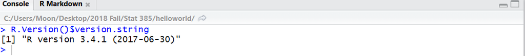

R version

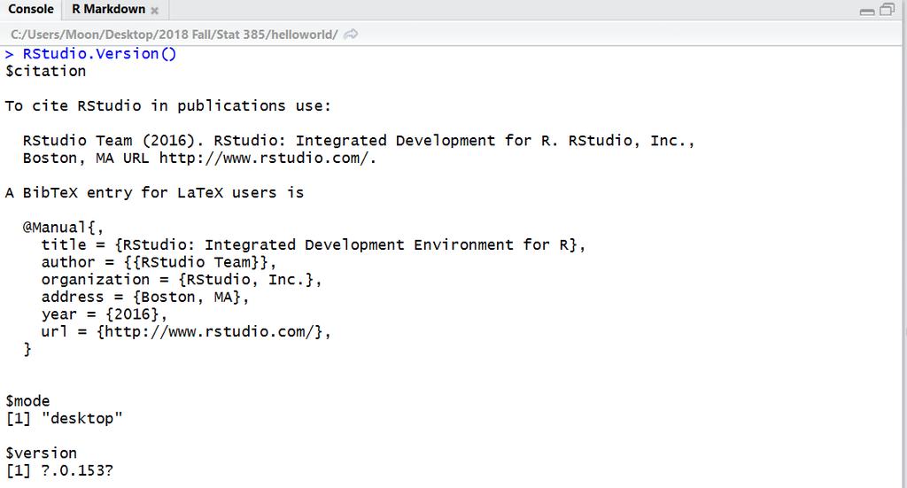

Rstudio 1.0.153

[figure not shown]

Git

[figure not shown]

Slack

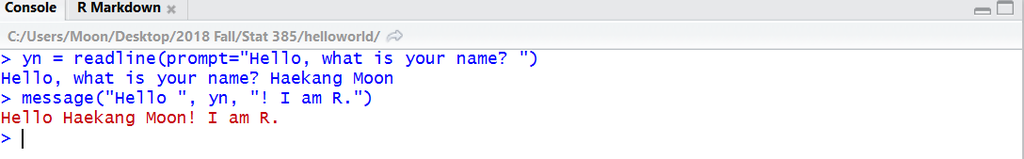

Verification

## Exercise 2

1. James Balamuta
2. Tech Plaza 212 F, Tuesday and Thursday from 9-10 AM in Room G36 of the Foreign Language Building.
3. That is not correct. [STAT 385]“Group project question”
4. Monday, Wednesday, and Friday, 2:00 PM - 2:50 PM, 218 Mechanical Engineering Bldg
5. One midterm, The midterm will have an in-class portion and may have a take-home portion that will be due within 24-48 hours after the start of the exam.
6. There are 4 phases and each 100 pts. 40 % of overall grade. It depends on individual peer review.
7. HWs are encouraged to work together in a group of at most 3 students but must list the full names and netids on the top of documents. Each student must also turn in their own hw answers. Online code can be copy and paste as long as we cite where the code from.

## Exercise 4

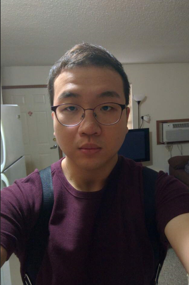

Self-Portrait

## List up in table

| item | Who I AM |
| --- | --- |
| *First Name* | Haekang |
| *Last Name* | Moon |
| *NETID* | moon49 |
| *Birthday* | 02/11 |
| *Year in School* | Senior |
| *Major* | Statistics |
| *Expected Graduation* | May 2018 |

## Ordered lists of my Favorite

1. foods
2. Music(https://www.youtube.com/watch?v=3VhMU5sVtdQ)
3. TV Shows
4. Movies

## Unordered lists

- Trip with Family to Canada
- Move in to new house
  $$\frac{\pi ^2 *r^2}{2}$$

## Write Formula

$$\Phi = \frac{1+\sqrt{5}}{2} = 1.6180339887...$$

## Pythagorus Theorem

$$a^2 +b^2 = c^2$$